# Binary-Class Tabular Model for Pistachio Identification Using Python and TensorFlow Decision Forests

### July 19, 2022

SUMMARY: The project aims to construct a predictive model using various machine learning algorithms and document the end-to-end steps using a template. The Pistachio Identification dataset is a binary-class modeling situation where we attempt to predict one of two possible outcomes.

INTRODUCTION: Pistachio nut has an important place in the agricultural economy; the efficiency of post-harvest industrial processes is crucial to maintaining its economic value. The industry needs new methods and technologies for separating and classifying pistachios to provide this efficiency. In this study, the research team aimed to develop a classification model different from traditional separation methods based on image processing and artificial intelligence techniques.

A computer vision system (CVS) has been developed to distinguish two species of pistachios with different characteristics that address additional market types. The research team took 2148 sample images for these two kinds of pistachios with a high-resolution camera. They applied image processing, segmentation, and feature extraction techniques to the images of the pistachio samples.

ANALYSIS: The performance of the preliminary Gradient Boosted Trees model achieved an accuracy benchmark of 99.30% on the training dataset. When we applied the finalized model to the test dataset, the model achieved an accuracy score of 90.93%.

CONCLUSION: In this iteration, the Gradient Boosted Trees model appeared to be a suitable algorithm for modeling this dataset.

Dataset Used: Pistachio Dataset

Dataset ML Model: Binary classification with numerical features

Dataset Reference: https://www.muratkoklu.com/datasets/

One source of potential performance benchmarks: https://doi.org/10.23751/pn.v23i2.9686

## Task 1 - Prepare Environment

```python
# Install TensorFlow Decision Forests.
!pip3 install tensorflow_decision_forests --upgrade
```

[output not shown]

```python
# Retrieve the CPU information
ncpu = !nproc
print("The number of available CPUs is:", ncpu[0])
```

```
The number of available CPUs is: 2
```

### 1.a) Load libraries and modules

```python
# Set the random seed number for reproducible results
RNG_SEED = 888
```

```python
import random
random.seed(RNG_SEED)
import numpy as np
np.random.seed(RNG_SEED)
import pandas as pd
import seaborn as sns
import matplotlib
import matplotlib.pyplot as plt
import os
import sys
import math
# import boto3
import zipfile
from datetime import datetime
from sklearn import preprocessing
from sklearn.model_selection import train_test_split
from sklearn.model_selection import RepeatedKFold
from sklearn.metrics import classification_report
from sklearn.metrics import confusion_matrix
from sklearn.metrics import accuracy_score
from sklearn.pipeline import Pipeline
from sklearn import compose
from sklearn import impute
from sklearn import metrics
import tensorflow as tf
tf.random.set_seed(RNG_SEED)
# from tensorflow import keras
import tensorflow_decision_forests as tfdf
```

### 1.b) Set up the controlling parameters and functions

```python
# Begin the timer for the script processing
start_time_script = datetime.now()

# Set up the number of CPU cores available for multi-thread processing
N_JOBS = 1

# Set up the flag to stop sending progress emails (setting to True will send status emails!)
NOTIFY_STATUS = False

# Set the percentage sizes for splitting the dataset
TEST_SET_RATIO = 0.2
VAL_SET_RATIO = 0.2

# Set the name for the class/label column
ORIGINAL_LABEL = 'Class'
CLASS_COLUMN = 'target'

# Set the number of folds for cross validation
N_FOLDS = 5
N_ITERATIONS = 1

# Set various default modeling parameters
DEFAULT_METRICS = ["accuracy", tf.keras.metrics.BinaryCrossentropy()]

# Define the directory locations and file names
TRAIN_DATASET = 'Pistachio_28_Features_Dataset.arff'

# Print out the TensorFlow version for confirmation
print('TensorFlow version:', tf.__version__)

# Check the version of TensorFlow Decision Forests
print("Found TensorFlow Decision Forests v" + tfdf.__version__)
```

```
TensorFlow version: 2.9.1
Found TensorFlow Decision Forests v0.2.6
```

```python
# Set up the email notification function
def status_notify(msg_text):
    access_key = os.environ.get('SNS_ACCESS_KEY')
    secret_key = os.environ.get('SNS_SECRET_KEY')
    aws_region = os.environ.get('SNS_AWS_REGION')
    topic_arn = os.environ.get('SNS_TOPIC_ARN')
    if (access_key is None) or (secret_key is None) or (aws_region is None):
        sys.exit("Incomplete notification setup info. Script Processing Aborted!!!")
    sns = boto3.client('sns', aws_access_key_id=access_key, aws_secret_access_key=secret_key, region_name=aws_region)
    response = sns.publish(TopicArn=topic_arn, Message=msg_text)
    if response['ResponseMetadata']['HTTPStatusCode'] != 200 :
        print('Status notification not OK with HTTP status code:', response['ResponseMetadata']['HTTPStatusCode'])
```

```python
if NOTIFY_STATUS: status_notify("Task 1 - Prepare Environment has begun! " + datetime.now().strftime('%a %B %d, %Y %I:%M:%S %p'))
```

### 1.c) Load dataset

```python
dataset_path = 'https://dainesanalytics.com/datasets/muratkoklu-pistachio-datasets/Tabular_Image_Datasets/Pistachio_28_Features_Dataset/Pistachio_28_Features_Dataset.arff'
colNames = ['Area','Perimeter','MajorAxis','MinorAxis','Eccentricity','Eqdiasq','Solidity',
            'Convex_Area','Extent','Aspect_Ratio','Roundness','Compactness','ShapeFactor1','ShapeFactor2',
            'ShapeFactor3','ShapeFactor4','Mean_RR','Mean_RG','Mean_RB','StdDev_RR','StdDev_RG',
            'StdDev_RB','Skew_RR','Skew_RG','Skew_RB','Kurtosis_RR','Kurtosis_RG','Kurtosis_RB',
            'Class']
df_dataset_import = pd.read_csv(dataset_path, names=colNames, sep=',', header=None, index_col=False, skiprows=42)

# Take a peek at the dataframe after import
print(df_dataset_import.head())
```

```
    Area  Perimeter  MajorAxis  MinorAxis  Eccentricity   Eqdiasq  Solidity  \
0  63391   1568.405   390.3396   236.7461        0.7951  284.0984    0.8665
1  68358   1942.187   410.8594   234.7525        0.8207  295.0188    0.8765
2  73589   1246.538   452.3630   220.5547        0.8731  306.0987    0.9172
3  71106   1445.261   429.5291   216.0765        0.8643  300.8903    0.9589
4  80087   1251.524   469.3783   220.9344        0.8823  319.3273    0.9657

   Convex_Area  Extent  Aspect_Ratio  ...  StdDev_RR  StdDev_RG  StdDev_RB  \
0        73160  0.6394        1.6488  ...    17.7206    19.6024    21.1342
1        77991  0.6772        1.7502  ...    26.7061    27.2112    25.1035
2        80234  0.7127        2.0510  ...    19.0129    20.0703    20.7006
3        74153  0.7028        1.9879  ...    18.1773    18.7152    29.7883
4        82929  0.7459        2.1245  ...    23.4298    24.0878    23.1157

   Skew_RR  Skew_RG  Skew_RB  Kurtosis_RR  Kurtosis_RG  Kurtosis_RB  \
0   0.4581   0.6635   0.7591       2.9692       3.0576       2.9542
1  -0.3847  -0.2713  -0.2927       1.9807       2.1006       2.2152
2  -0.6014  -0.4500   0.2998       3.5420       3.6856       4.1012
3  -0.6943  -0.6278  -0.7798       2.8776       2.8748       2.8953
4  -0.9287  -0.8134  -0.4970       2.9915       2.8813       2.7362

               Class
0  Kirmizi_Pistachio
1  Kirmizi_Pistachio
2  Kirmizi_Pistachio
3  Kirmizi_Pistachio
4  Kirmizi_Pistachio

[5 rows x 29 columns]
```

```python
df_dataset_import.info(verbose=True)
```

```
<class 'pandas.core.frame.DataFrame'>
RangeIndex: 2148 entries, 0 to 2147
Data columns (total 29 columns):
 #   Column        Non-Null Count  Dtype
---  ------        --------------  -----
 0   Area          2148 non-null   int64
 1   Perimeter     2148 non-null   float64
 2   MajorAxis     2148 non-null   float64
 3   MinorAxis     2148 non-null   float64
 4   Eccentricity  2148 non-null   float64
 5   Eqdiasq       2148 non-null   float64
 6   Solidity      2148 non-null   float64
 7   Convex_Area   2148 non-null   int64
 8   Extent        2148 non-null   float64
 9   Aspect_Ratio  2148 non-null   float64
```

[output cut: 21 more lines]

```python
print(df_dataset_import.describe())
```

```
                Area    Perimeter    MajorAxis    MinorAxis  Eccentricity  \
count    2148.000000  2148.000000  2148.000000  2148.000000   2148.000000
mean    79950.655493  1425.971751   446.248968   238.311842      0.840219
std     13121.737799   375.565503    32.445304    30.310695      0.048759
min     29808.000000   858.363000   320.344500   133.509600      0.504900
25%     71936.750000  1170.996250   426.508750   217.875825      0.817500
50%     79905.500000  1262.785500   448.574750   236.416350      0.849650
75%     89030.500000  1607.906250   468.509400   257.760150      0.875200
max    124008.000000  2755.049100   541.966100   383.046100      0.946000

           Eqdiasq     Solidity    Convex_Area       Extent  Aspect_Ratio  \
count  2148.000000  2148.000000    2148.000000  2148.000000   2148.000000
mean    317.919173     0.940093   85015.839851     0.716067      1.898154
std      26.908600     0.050452   13154.919327     0.052532      0.240100
min     194.814600     0.588000   37935.000000     0.427200      1.158500
25%     302.642850     0.919850   76467.000000     0.687000      1.736375
50%     318.965300     0.954150   85075.500000     0.726500      1.896250
75%     336.685525     0.976925   93893.500000     0.753600      2.067025
max     397.356100     0.995100  132478.000000     0.820400      3.085800

       ...      Mean_RB    StdDev_RR    StdDev_RG    StdDev_RB      Skew_RR  \
count  ...  2148.000000  2148.000000  2148.000000  2148.000000  2148.000000
mean   ...   191.995311    21.380084    22.591454    22.427056    -0.735243
std    ...    13.030505     3.127813     3.622222     3.926325     0.384584
min    ...   146.787600    10.611100    11.985400    11.197100    -1.931600
25%    ...   182.930675    19.253550    20.036675    19.722425    -0.990900
50%    ...   192.036350    21.425100    22.523250    22.276900    -0.756600
75%    ...   201.097725    23.695900    25.241900    25.140125    -0.502500
max    ...   235.000700    30.838300    33.614600    42.756600     1.865400

           Skew_RG      Skew_RB  Kurtosis_RR  Kurtosis_RG  Kurtosis_RB
count  2148.000000  2148.000000  2148.000000  2148.000000  2148.000000
mean     -0.615580    -0.367142     3.054000     2.903015     2.940572
std       0.389219     0.426964     0.733993     0.651383     0.750171
min      -1.658200    -2.348600     1.662400     1.665500     1.522500
25%      -0.875975    -0.645800     2.509700     2.437400     2.449425
50%      -0.653050    -0.424550     2.941750     2.807050     2.783350
75%      -0.405000    -0.158400     3.446500     3.247400     3.224650
max       2.257600     1.852100     8.890600    10.453900    11.533900

[8 rows x 28 columns]
```

```python
print(df_dataset_import.isnull().sum())
print('Total number of NaN in the dataframe: ', df_dataset_import.isnull().sum().sum())
```

```
Area            0
Perimeter       0
MajorAxis       0
MinorAxis       0
Eccentricity    0
Eqdiasq         0
Solidity        0
Convex_Area     0
Extent          0
Aspect_Ratio    0
Roundness       0
Compactness     0
ShapeFactor1    0
ShapeFactor2    0
ShapeFactor3    0
ShapeFactor4    0
Mean_RR         0
Mean_RG         0
Mean_RB         0
StdDev_RR       0
StdDev_RG       0
StdDev_RB       0
Skew_RR         0
Skew_RG         0
Skew_RB         0
Kurtosis_RR     0
Kurtosis_RG     0
Kurtosis_RB     0
Class           0
dtype: int64
Total number of NaN in the dataframe:  0
```

```python
# Get grouping size for the target variable
print(df_dataset_import.groupby(ORIGINAL_LABEL).size())
```

```
Class
Kirmizi_Pistachio    1232
Siirt_Pistachio       916
dtype: int64
```

### 1.d) Data Cleaning

```python
# Standardize the class column to the name of targetVar if required
df_dataset_import = df_dataset_import.rename(columns={ORIGINAL_LABEL: CLASS_COLUMN})

# Transform the classes into integers
label_encoder = preprocessing.LabelEncoder()
df_dataset_import[CLASS_COLUMN] = label_encoder.fit_transform(df_dataset_import[CLASS_COLUMN])

# Take a peek at the dataframe after cleaning
print(df_dataset_import.head())
```

```
    Area  Perimeter  MajorAxis  MinorAxis  Eccentricity   Eqdiasq  Solidity  \
0  63391   1568.405   390.3396   236.7461        0.7951  284.0984    0.8665
1  68358   1942.187   410.8594   234.7525        0.8207  295.0188    0.8765
2  73589   1246.538   452.3630   220.5547        0.8731  306.0987    0.9172
3  71106   1445.261   429.5291   216.0765        0.8643  300.8903    0.9589
4  80087   1251.524   469.3783   220.9344        0.8823  319.3273    0.9657

   Convex_Area  Extent  Aspect_Ratio  ...  StdDev_RR  StdDev_RG  StdDev_RB  \
0        73160  0.6394        1.6488  ...    17.7206    19.6024    21.1342
1        77991  0.6772        1.7502  ...    26.7061    27.2112    25.1035
2        80234  0.7127        2.0510  ...    19.0129    20.0703    20.7006
3        74153  0.7028        1.9879  ...    18.1773    18.7152    29.7883
4        82929  0.7459        2.1245  ...    23.4298    24.0878    23.1157

   Skew_RR  Skew_RG  Skew_RB  Kurtosis_RR  Kurtosis_RG  Kurtosis_RB  target
0   0.4581   0.6635   0.7591       2.9692       3.0576       2.9542       0
1  -0.3847  -0.2713  -0.2927       1.9807       2.1006       2.2152       0
2  -0.6014  -0.4500   0.2998       3.5420       3.6856       4.1012       0
3  -0.6943  -0.6278  -0.7798       2.8776       2.8748       2.8953       0
4  -0.9287  -0.8134  -0.4970       2.9915       2.8813       2.7362       0

[5 rows x 29 columns]
```

```python
df_dataset_import.info(verbose=True)
```

```
<class 'pandas.core.frame.DataFrame'>
RangeIndex: 2148 entries, 0 to 2147
Data columns (total 29 columns):
 #   Column        Non-Null Count  Dtype
---  ------        --------------  -----
 0   Area          2148 non-null   int64
 1   Perimeter     2148 non-null   float64
 2   MajorAxis     2148 non-null   float64
 3   MinorAxis     2148 non-null   float64
 4   Eccentricity  2148 non-null   float64
 5   Eqdiasq       2148 non-null   float64
 6   Solidity      2148 non-null   float64
 7   Convex_Area   2148 non-null   int64
 8   Extent        2148 non-null   float64
 9   Aspect_Ratio  2148 non-null   float64
```

[output cut: 21 more lines]

```python
print(df_dataset_import.describe())
```

```
                Area    Perimeter    MajorAxis    MinorAxis  Eccentricity  \
count    2148.000000  2148.000000  2148.000000  2148.000000   2148.000000
mean    79950.655493  1425.971751   446.248968   238.311842      0.840219
std     13121.737799   375.565503    32.445304    30.310695      0.048759
min     29808.000000   858.363000   320.344500   133.509600      0.504900
25%     71936.750000  1170.996250   426.508750   217.875825      0.817500
50%     79905.500000  1262.785500   448.574750   236.416350      0.849650
75%     89030.500000  1607.906250   468.509400   257.760150      0.875200
max    124008.000000  2755.049100   541.966100   383.046100      0.946000

           Eqdiasq     Solidity    Convex_Area       Extent  Aspect_Ratio  \
count  2148.000000  2148.000000    2148.000000  2148.000000   2148.000000
mean    317.919173     0.940093   85015.839851     0.716067      1.898154
std      26.908600     0.050452   13154.919327     0.052532      0.240100
min     194.814600     0.588000   37935.000000     0.427200      1.158500
25%     302.642850     0.919850   76467.000000     0.687000      1.736375
50%     318.965300     0.954150   85075.500000     0.726500      1.896250
75%     336.685525     0.976925   93893.500000     0.753600      2.067025
max     397.356100     0.995100  132478.000000     0.820400      3.085800

       ...    StdDev_RR    StdDev_RG    StdDev_RB      Skew_RR      Skew_RG  \
count  ...  2148.000000  2148.000000  2148.000000  2148.000000  2148.000000
mean   ...    21.380084    22.591454    22.427056    -0.735243    -0.615580
std    ...     3.127813     3.622222     3.926325     0.384584     0.389219
min    ...    10.611100    11.985400    11.197100    -1.931600    -1.658200
25%    ...    19.253550    20.036675    19.722425    -0.990900    -0.875975
50%    ...    21.425100    22.523250    22.276900    -0.756600    -0.653050
75%    ...    23.695900    25.241900    25.140125    -0.502500    -0.405000
max    ...    30.838300    33.614600    42.756600     1.865400     2.257600

           Skew_RB  Kurtosis_RR  Kurtosis_RG  Kurtosis_RB       target
count  2148.000000  2148.000000  2148.000000  2148.000000  2148.000000
mean     -0.367142     3.054000     2.903015     2.940572     0.426443
std       0.426964     0.733993     0.651383     0.750171     0.494675
min      -2.348600     1.662400     1.665500     1.522500     0.000000
25%      -0.645800     2.509700     2.437400     2.449425     0.000000
50%      -0.424550     2.941750     2.807050     2.783350     0.000000
75%      -0.158400     3.446500     3.247400     3.224650     1.000000
max       1.852100     8.890600    10.453900    11.533900     1.000000

[8 rows x 29 columns]
```

```python
print(df_dataset_import.isnull().sum())
print('Total number of NaN in the dataframe: ', df_dataset_import.isnull().sum().sum())
```

```
Area            0
Perimeter       0
MajorAxis       0
MinorAxis       0
Eccentricity    0
Eqdiasq         0
Solidity        0
Convex_Area     0
Extent          0
Aspect_Ratio    0
Roundness       0
Compactness     0
ShapeFactor1    0
ShapeFactor2    0
ShapeFactor3    0
ShapeFactor4    0
Mean_RR         0
Mean_RG         0
Mean_RB         0
StdDev_RR       0
StdDev_RG       0
StdDev_RB       0
Skew_RR         0
Skew_RG         0
Skew_RB         0
Kurtosis_RR     0
Kurtosis_RG     0
Kurtosis_RB     0
target          0
dtype: int64
Total number of NaN in the dataframe:  0
```

```python
# Get grouping size for the target variable
print(df_dataset_import.groupby(CLASS_COLUMN).size())
```

```
target
0    1232
1     916
dtype: int64
```

### 1.e) Splitting Data into Sets

```python
# Split the data further into training and test datasets
df_dataset_train, df_dataset_test = train_test_split(df_dataset_import, test_size=TEST_SET_RATIO, random_state=RNG_SEED,
                                                     stratify=df_dataset_import['target'])
print("df_dataset_train.shape: {} df_dataset_test.shape: {}".format(df_dataset_train.shape, df_dataset_test.shape))
```

```
df_dataset_train.shape: (1718, 29) df_dataset_test.shape: (430, 29)
```

```python
# Use variable total_column_count to hold the number of columns in the dataframe
total_column_count = len(df_dataset_import.columns)

# Set up variable total_feature_count for the total number of attribute columns
total_feature_count = total_column_count-1

# We create attribute-only and target-only datasets (df_features_train and df_target_train)
df_target_train = df_dataset_train['target']
df_features_train = df_dataset_train.drop(['target'], axis=1)

print("df_dataset_train.shape: {} df_features_train.shape: {} df_target_train.shape: {}".format(df_dataset_train.shape, df_features_train.shape, df_target_train.shape))
```

```
df_dataset_train.shape: (1718, 29) df_features_train.shape: (1718, 28) df_target_train.shape: (1718,)
```

### 1.f) Set up the parameters for data visualization

```python
# Set up the number of row and columns for visualization display. display_rows * display_columns should be >= total_feature_count
display_columns = 4
if total_feature_count % display_columns == 0 :
    display_rows = total_feature_count // display_columns
else :
    display_rows = (total_feature_count // display_columns) + 1

# Set figure width to display the data visualization plots
fig_size = plt.rcParams["figure.figsize"]
fig_size[0] = display_columns * 4
fig_size[1] = display_rows * 4
plt.rcParams["figure.figsize"] = fig_size
```

```python
if NOTIFY_STATUS: status_notify("Task 1 - Prepare Environment completed! "+datetime.now().strftime('%a %B %d, %Y %I:%M:%S %p'))
```

## Task 2 - Summarize and Visualize Data

```python
if NOTIFY_STATUS: status_notify("Task 2 - Summarize and Visualize Data has begun! "+datetime.now().strftime('%a %B %d, %Y %I:%M:%S %p'))
```

[figure not shown]

```python
# Histograms for each attribute
df_features_train.plot(kind='hist', subplots=True, layout=(display_rows, display_columns))
plt.show()
```

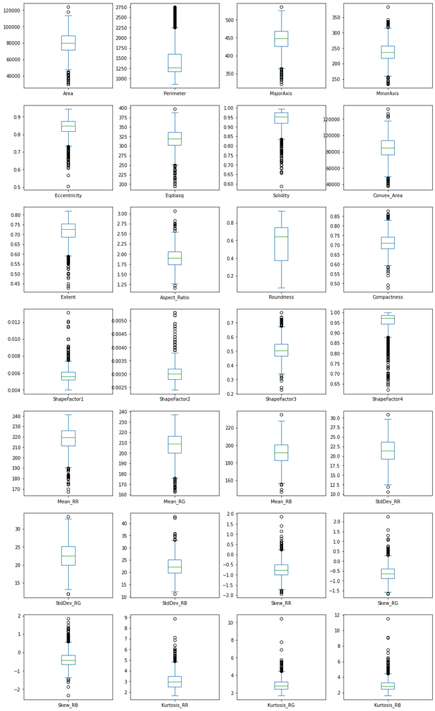

```python
# Box and Whisker plot for each attribute
df_features_train.plot(kind='box', subplots=True, layout=(display_rows, display_columns))
plt.show()
```

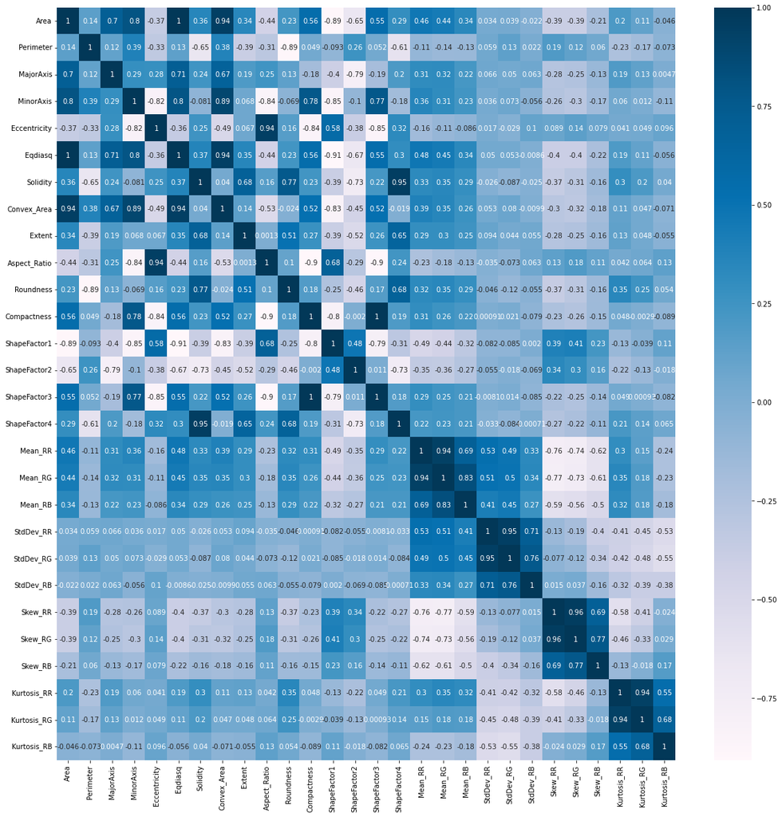

```python
# Correlation matrix
fig = plt.figure(figsize=(20, 20))
correlations = df_features_train.corr(method='pearson')
sns.heatmap(correlations, annot=True, cmap=plt.cm.PuBu)
plt.show()
```

```python
if NOTIFY_STATUS: status_notify("Task 2 - Summarize and Visualize Data completed! "+datetime.now().strftime('%a %B %d, %Y %I:%M:%S %p'))
```

## Task 3 - Train and Evaluate Models

```python
if NOTIFY_STATUS: status_notify("Task 3 - Train and Evaluate Models has begun! "+datetime.now().strftime('%a %B %d, %Y %I:%M:%S %p'))
```

### 3.a) Splitting Data into Training and Validation Sets

```python
# Finalize the training and validation datasets for the modeling activities
tfds_train = tfdf.keras.pd_dataframe_to_tf_dataset(df_dataset_train, label='target', task = tfdf.keras.Task.CLASSIFICATION)
```

### 3.b) Train and Evaluate the Random Forest Model

```python
# Define the baseline model for benchmarking
start_time_module = datetime.now()
tf.keras.utils.set_random_seed(RNG_SEED)
RF_model = tfdf.keras.RandomForestModel(task = tfdf.keras.Task.CLASSIFICATION)
RF_model.compile(metrics=DEFAULT_METRICS)

# "sys_pipes" is optional. It enables the display of the training logs.
# with sys_pipes():
#     RF_model.fit(x=tfds_train)

# Train the model.
RF_model.fit(x=tfds_train)
print ('Model training time:', (datetime.now() - start_time_module), '\n')
```

```
Use /tmp/tmpjpgt2r1o as temporary training directory
Reading training dataset...
Training dataset read in 0:00:05.803084. Found 1718 examples.
Training model...
Model trained in 0:00:01.379912
Compiling model...
WARNING:tensorflow:AutoGraph could not transform <function simple_ml_inference_op_with_handle at 0x7fa98b64f830> and will run it as-is.
Please report this to the TensorFlow team. When filing the bug, set the verbosity to 10 (on Linux, `export AUTOGRAPH_VERBOSITY=10`) and attach the full output.
Cause: could not get source code
To silence this warning, decorate the function with @tf.autograph.experimental.do_not_convert
```

[output not shown]

```
WARNING: AutoGraph could not transform <function simple_ml_inference_op_with_handle at 0x7fa98b64f830> and will run it as-is.
Please report this to the TensorFlow team. When filing the bug, set the verbosity to 10 (on Linux, `export AUTOGRAPH_VERBOSITY=10`) and attach the full output.
Cause: could not get source code
To silence this warning, decorate the function with @tf.autograph.experimental.do_not_convert
Model compiled.
Model training time: 0:00:09.342970
```

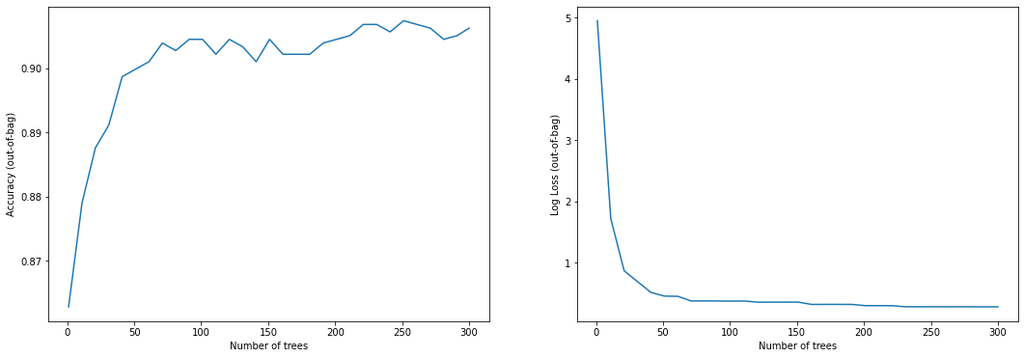

```python
logs = RF_model.make_inspector().training_logs()

plt.figure(figsize=(18, 6))
plt.subplot(1, 2, 1)
plt.plot([log.num_trees for log in logs], [log.evaluation.accuracy for log in logs])
plt.xlabel("Number of trees")
plt.ylabel("Accuracy (out-of-bag)")
plt.subplot(1, 2, 2)
plt.plot([log.num_trees for log in logs], [log.evaluation.loss for log in logs])
plt.xlabel("Number of trees")
plt.ylabel("Log Loss (out-of-bag)")
plt.show()
```

```python
RF_eval = RF_model.evaluate(tfds_train, return_dict=True)
print()

for name, value in RF_eval.items():
    print(f"{name}: {value:.4f}")
```

```
loss: 0.0000
accuracy: 0.9814
binary_crossentropy: 0.1026
```

### 3.c) Train and Evaluate the Decision Trees Model

```python
# Define the baseline model for benchmarking
start_time_module = datetime.now()
tf.keras.utils.set_random_seed(RNG_SEED)
CART_model = tfdf.keras.CartModel(task = tfdf.keras.Task.CLASSIFICATION)
CART_model.compile(metrics=DEFAULT_METRICS)

# "sys_pipes" is optional. It enables the display of the training logs.
# with sys_pipes():
#     CART_model.fit(x=tfds_train)

# Train the model.
CART_model.fit(x=tfds_train)
print ('Model training time:', (datetime.now() - start_time_module), '\n')
```

```
Use /tmp/tmpwh3z2i7z as temporary training directory
Reading training dataset...
Training dataset read in 0:00:00.503938. Found 1718 examples.
Training model...
Model trained in 0:00:00.026094
Compiling model...
Model compiled.
Model training time: 0:00:01.770147
```

```python
CART_eval = CART_model.evaluate(tfds_train, return_dict=True)
print()

for name, value in CART_eval.items():
    print(f"{name}: {value:.4f}")
```

```
loss: 0.0000
accuracy: 0.8981
binary_crossentropy: 0.1938
```

### 3.d) Train and Evaluate the Gradient Boosted Trees Model

```python
# Define the baseline model for benchmarking
start_time_module = datetime.now()
tf.keras.utils.set_random_seed(RNG_SEED)
GBT_model = tfdf.keras.GradientBoostedTreesModel(task = tfdf.keras.Task.CLASSIFICATION)
GBT_model.compile(metrics=DEFAULT_METRICS)

# "sys_pipes" is optional. It enables the display of the training logs.
# with sys_pipes():
#     GBT_model.fit(x=tfds_train)

# Train the model.
GBT_model.fit(x=tfds_train)
print ('Model training time:', (datetime.now() - start_time_module), '\n')
```

```
Use /tmp/tmp16081h7l as temporary training directory
Reading training dataset...
Training dataset read in 0:00:00.592116. Found 1718 examples.
Training model...
Model trained in 0:00:02.435296
Compiling model...
Model compiled.
Model training time: 0:00:03.408704
```

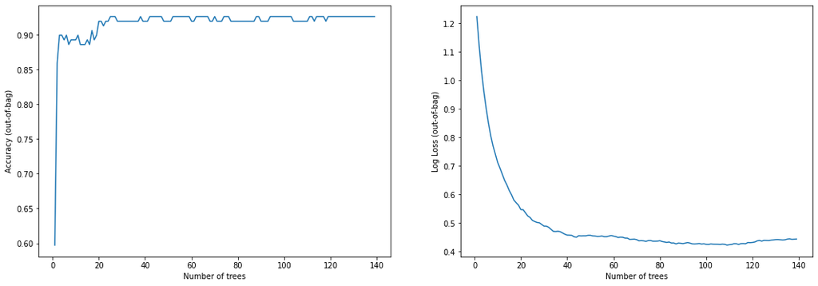

```python
logs = GBT_model.make_inspector().training_logs()

plt.figure(figsize=(18, 6))
plt.subplot(1, 2, 1)
plt.plot([log.num_trees for log in logs], [log.evaluation.accuracy for log in logs])
plt.xlabel("Number of trees")
plt.ylabel("Accuracy (out-of-bag)")
plt.subplot(1, 2, 2)
plt.plot([log.num_trees for log in logs], [log.evaluation.loss for log in logs])
plt.xlabel("Number of trees")
plt.ylabel("Log Loss (out-of-bag)")
plt.show()
```

```python
GBT_eval = GBT_model.evaluate(tfds_train, return_dict=True)
print()

for name, value in GBT_eval.items():
    print(f"{name}: {value:.4f}")
```

```
loss: 0.0000
accuracy: 0.9930
binary_crossentropy: 0.1422
```

```python
if NOTIFY_STATUS: status_notify("Task 4 - Train and Evaluate Models completed! "+datetime.now().strftime('%a %B %d, %Y %I:%M:%S %p'))
```

## Task 4 - Fine-tune and Improve Models

```python
if NOTIFY_STATUS: status_notify("Task 4 - Fine-tune and Improve Models has begun! "+datetime.now().strftime('%a %B %d, %Y %I:%M:%S %p'))
```

```python
# Not applicable for this iteration of modeling
```

```python
if NOTIFY_STATUS: status_notify("Task 4 - Fine-tune and Improve Models completed! "+datetime.now().strftime('%a %B %d, %Y %I:%M:%S %p'))
```

## Task 5 - Finalize Model and Present Analysis

```python
if NOTIFY_STATUS: status_notify("Task 5 - Finalize Model and Present Analysis has begun! "+datetime.now().strftime('%a %B %d, %Y %I:%M:%S %p'))
```

### 5.a) Train the Final Model

```python
# Define the baseline model for benchmarking
start_time_module = datetime.now()
tf.keras.utils.set_random_seed(RNG_SEED)
# final_model = tfdf.keras.RandomForestModel(task = tfdf.keras.Task.CLASSIFICATION)
# final_model = tfdf.keras.CartModel(task = tfdf.keras.Task.CLASSIFICATION)
final_model = tfdf.keras.GradientBoostedTreesModel(task = tfdf.keras.Task.CLASSIFICATION)

# Optionally, add evaluation metrics.
final_model.compile(metrics=DEFAULT_METRICS)

# "sys_pipes" is optional. It enables the display of the training logs.
# with sys_pipes():
#     final_model.fit(x=tfds_train)

# Train the model.
final_model.fit(x=tfds_train)
print ('Model training time:', (datetime.now() - start_time_module), '\n')
```

```
Use /tmp/tmpbdo6hns9 as temporary training directory
Reading training dataset...
Training dataset read in 0:00:00.524492. Found 1718 examples.
Training model...
Model trained in 0:00:02.460023
Compiling model...
Model compiled.
Model training time: 0:00:05.622462
```

```python
final_model.summary()
```

```
Model: "gradient_boosted_trees_model_1"
_________________________________________________________________
 Layer (type)                Output Shape              Param #
=================================================================
=================================================================
Total params: 1
Trainable params: 0
Non-trainable params: 1
_________________________________________________________________
Type: "GRADIENT_BOOSTED_TREES"
Task: CLASSIFICATION
Label: "__LABEL"

Input Features (28):
	Area
	Aspect_Ratio
	Compactness
	Convex_Area
	Eccentricity
	Eqdiasq
	Extent
	Kurtosis_RB
	Kurtosis_RG
	Kurtosis_RR
	MajorAxis
	Mean_RB
	Mean_RG
	Mean_RR
	MinorAxis
	Perimeter
	Roundness
	ShapeFactor1
	ShapeFactor2
	ShapeFactor3
	ShapeFactor4
	Skew_RB
	Skew_RG
	Skew_RR
	Solidity
	StdDev_RB
```

[output cut: 345 more lines]

```
	23 : MajorAxis [NUMERICAL]
	6 : ShapeFactor2 [NUMERICAL]

Condition type in nodes:
	2303 : HigherCondition
Condition type in nodes with depth <= 0:
	109 : HigherCondition
Condition type in nodes with depth <= 1:
	320 : HigherCondition
Condition type in nodes with depth <= 2:
	703 : HigherCondition
Condition type in nodes with depth <= 3:
	1333 : HigherCondition
Condition type in nodes with depth <= 5:
	2303 : HigherCondition
```

### 5.b) Load Test Dataset and Make Predictions

```python
# Finalize the test dataset for the prediction activities
tfds_test = tfdf.keras.pd_dataframe_to_tf_dataset(df_dataset_test, label='target', task = tfdf.keras.Task.CLASSIFICATION)
```

```python
final_eval = final_model.evaluate(tfds_test, return_dict=True)
print()

for name, value in final_eval.items():
    print(f"{name}: {value:.4f}")
```

```
loss: 0.0000
accuracy: 0.9093
binary_crossentropy: 0.1508
```

```python
if NOTIFY_STATUS: status_notify("Task 5 - Finalize Model and Present Analysis completed! "+datetime.now().strftime('%a %B %d, %Y %I:%M:%S %p'))
```

```python
print ('Total time for the script:',(datetime.now() - start_time_script))
```

```
Total time for the script: 0:00:56.176960
```